# Estimating Risk Surface

# Preliminary tasks

## Preparation

This notebook estimates a spatial risk surface for maternal deaths in Kano, Nigeria, based on the kernel density ratio method: https://arxiv.org/pdf/1707.06888

Key optimizations applied: - WorldPop raster is aggregated before point generation to reduce memory load - Population points are capped at a maximum sample size (10,000) - Fixed bandwidth used first for speed; adaptive bandwidth optional - Duplicate chunk names fixed - Cases/Controls variable naming corrected

### Install required packages

### Load required packages

# Load Data

## Model outputs

## Maternal deaths (Cases)

## Study area boundary

# Validation: Test with built-in PBC dataset

```r
data(pbc)
pbccas <- split(pbc)$case
pbccon <- split(pbc)$control
```

# Main Analysis: Maternal Death Risk Surface in Kano

## Step 1: Reproject all data to UTM Zone 32N

# spatstat’s as.owin() requires a projected coordinate system (metres),

# not geographic coordinates (degrees). WGS84 will cause as.owin() to fail.

# UTM Zone 32N (EPSG:32632) is appropriate for Kano, Nigeria.

# All datasets must use the same CRS for ppp objects to align correctly.

```r
CRS_UTM <- 32632

kano_proj           <- sf::st_transform(kano, crs = CRS_UTM)
maternal_deaths_proj <- sf::st_transform(maternal_deaths, crs = CRS_UTM)

cat("All data reprojected to UTM Zone 32N\n")
```

```
All data reprojected to UTM Zone 32N
```

## Step 2: Filter maternal deaths to Kano study area

# maternal_deaths contains records from the wider Kano region.

# Deaths outside the study area boundary have no corresponding

# population Controls and would bias the risk surface.

```r
maternal_deaths_kano <- sf::st_filter(maternal_deaths_proj, kano_proj)
cat("Deaths within Kano study area:", nrow(maternal_deaths_kano),
    "out of", nrow(maternal_deaths_proj), "\n")
```

```
Deaths within Kano study area: 28 out of 78
```

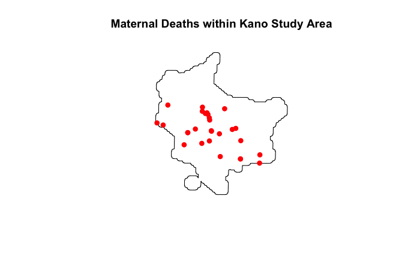

```r
# Visual check
plot(sf::st_geometry(kano_proj), main = "Maternal Deaths within Kano Study Area")
plot(sf::st_geometry(maternal_deaths_kano), add = TRUE,
     col = "red", pch = 16, cex = 1.2)
```

## Step 3: Generate population points from WorldPop raster

# The original raster_to_random_points() generates points equal to the

# population value per cell (mean ~481, max ~8741), producing ~1.8M points

# and crashing R.

# Fix: scale down all values by SCALE_FACTOR before generating points.

# A cell with 500 women gets 5 points, a cell with 8741 gets 87 points.

# Relative proportions are preserved so the kernel density estimate is

# mathematically equivalent to the original approach.

# pmax(1, …) ensures every cell contributes at least 1 point.

## Step 4: Build spatial window from Kano polygon boundary

# Using the actual Kano boundary polygon (not a bounding box rectangle)

# ensures the risk surface matches the study area shape exactly.

# This requires projected coordinates - hence the UTM reprojection above.

```r
kano_poly   <- sf::st_cast(kano_proj, "POLYGON")
kano_window <- spatstat.geom::as.owin(kano_poly)
class(kano_window)
```

```
[1] "owin"
```

## Step 5: Create PPP objects

```r
# Cases: maternal deaths within Kano study area
deaths_coords <- sf::st_coordinates(maternal_deaths_kano)
deaths_ppp <- spatstat.geom::ppp(
  x      = deaths_coords[, 1],
  y      = deaths_coords[, 2],
  window = kano_window
)
cat("Deaths PPP:\n")
```

```
Deaths PPP:
```

```r
summary(deaths_ppp)
```

```
Planar point pattern:  28 points
Average intensity 1.685575e-08 points per square unit

Coordinates are given to 10 decimal places

Window: polygonal boundary
single connected closed polygon with 2676 vertices
enclosing rectangle: [423143.6, 476131.9] x [1297036.1, 1354226.5] units
                     (52990 x 57190 units)
Window area = 1661150000 square units
Fraction of frame area: 0.548
```

```r
# Controls: population at risk (women of childbearing age)
womenrepage_proj <- sf::st_transform(womenrepage, crs = 32632)

pop_coords <- sf::st_coordinates(womenrepage_proj)
pop_ppp    <- spatstat.geom::ppp(
  x      = pop_coords[, 1],
  y      = pop_coords[, 2],
  window = kano_window
)
summary(pop_ppp)
```

```
Planar point pattern:  9736 points
Average intensity 5.860985e-06 points per square unit

Coordinates are given to 10 decimal places

Window: polygonal boundary
single connected closed polygon with 2676 vertices
enclosing rectangle: [423143.6, 476131.9] x [1297036.1, 1354226.5] units
                     (52990 x 57190 units)
Window area = 1661150000 square units
Fraction of frame area: 0.548

*** 44 illegal points stored in attr(,“rejects”) ***
```

## Step 6: Estimate risk surface

### Option A: Fixed bandwidth (run first to verify everything works)

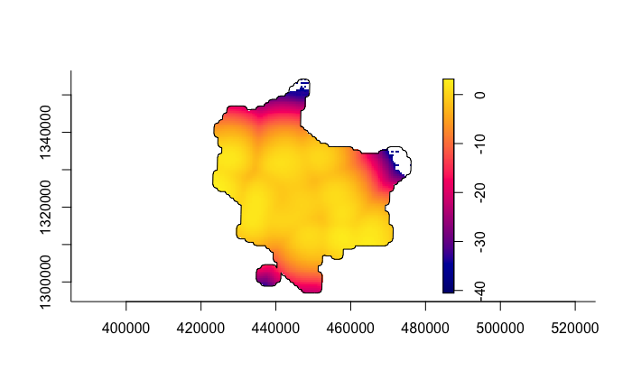

```r
rr_fixed <- risk(f = deaths_ppp, g = pop_ppp, doplot = TRUE)
```

```r
plot(rr_fixed, main = "Risk Surface - Fixed Bandwidth")
```

```
Error in plot.window(...) : need finite 'xlim' values
```

### Option B: Geometric bandwidth (recommended)

```r
h0 <- OS(deaths_ppp, nstar = "geometric")
cat("Optimal bandwidth:", h0, "\n")
```

```
Optimal bandwidth: 4759.528
```

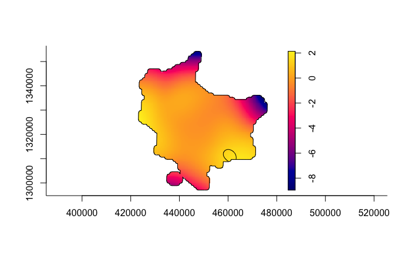

```r
rr_geom <- risk(
  f        = deaths_ppp,
  g        = pop_ppp,
  h0       = h0,
  tolerate = TRUE,
  doplot   = TRUE
)
```

```r
plot(rr_geom, main = "Risk Surface - Geometric Bandwidth")
```

```
Error in plot.window(...) : need finite 'xlim' values
```

### Option C: Adaptive bandwidth (most accurate, slowest)

# Set eval=TRUE in chunk header when ready to run - may take 10-30 mins

```r
hpilot.f <- BOOT.density(deaths_ppp)
hpilot.g <- BOOT.density(pop_ppp)

rr_adapt <- risk(
  f               = deaths_ppp,
  g               = pop_ppp,
  h0              = h0,
  adapt           = TRUE,
  tolerate        = TRUE,
  hp              = c(hpilot.f, hpilot.g),
  pilot.symmetry  = "pooled",
  davies.baddeley = 0.05
)
plot(rr_adapt, main = "Risk Surface - Adaptive Bandwidth")
```

[output not shown]

```r
# Convert risk surface to terra raster and set CRS
rr_raster <- terra::rast(rr_adapt$rr)
terra::crs(rr_raster) <- "EPSG:32632"

# Reproject to WGS84
rr_wgs84 <- terra::project(rr_raster, "EPSG:4326")

# Extract resolution directly from model output grid
res_x <- mean(data$lon_max - data$lon_min)
res_y <- mean(data$lat_max - data$lat_min)
cat("Model output resolution - x:", res_x, "y:", res_y, "\n")
```

```
Model output resolution - x: 0.001027334 y: 0.000815616
```

```r
# Create template from model output extent and resolution
template <- terra::rast(
  xmin       = min(data$lon_min),
  xmax       = max(data$lon_max),
  ymin       = min(data$lat_min),
  ymax       = max(data$lat_max),
  resolution = c(res_x, res_y),
  crs        = "EPSG:4326"
)

# Resample risk surface to match model output exactly
rr_resampled <- terra::resample(rr_wgs84, template, method = "bilinear")

cat("Original resolution:", terra::res(rr_wgs84), "\n")
```

```
Original resolution: 0.003923419 0.003923419
```

```r
cat("Resampled resolution:", terra::res(rr_resampled), "\n")
```

```
Resampled resolution: 0.001027334 0.000815616
```

## Step 8: Export results

```r
terra::writeRaster(rr_resampled,
                   "outputs/risk-surface-kano.tif",
                   overwrite = TRUE)
cat("GeoTIFF saved\n")
```

```r
png("outputs/risk-surface-kano.png", width = 1200, height = 900, res = 150)
plot(rr_resampled, main = "Maternal Death Risk Surface - Kano, Nigeria")
dev.off()
```

## make same resolution, 1km and 100m

check numeric of accessibility score check the categories of high medium and low (thresholds) maybe also try general healthcare model

Further analysis : 1. Bi-variate cluster analysis 2. Test only with the built up area

### calculate avg risk of high, medium and low

### compare the number, regression

### statistic analysis, max, min… volin plot

### Bi-variate cluster analysis, check different between clusters

### analysis build up area

## Step 9: Normalize risk surface to 0-1

```r
rr_min  <- terra::global(rr_resampled, "min", na.rm = TRUE)$min
rr_max  <- terra::global(rr_resampled, "max", na.rm = TRUE)$max
rr_norm <- (rr_resampled - rr_min) / (rr_max - rr_min)

cat("Normalized min:", terra::global(rr_norm, "min", na.rm = TRUE)$min, "\n")
```

```
Normalized min: 0
```

```r
cat("Normalized max:", terra::global(rr_norm, "max", na.rm = TRUE)$max, "\n")
```

```
Normalized max: 1
```

```r
terra::writeRaster(rr_norm,
                   "outputs/risk-surface-kano-normalized.tif",
                   overwrite = TRUE)
```

## Step 10: Density plot comparison

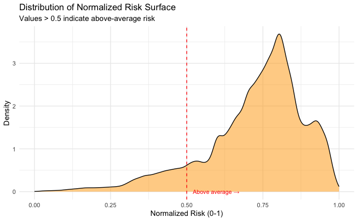

```r
# Density plots
# --- Normalized risk distribution ---
rr_norm_vec <- as.vector(terra::values(rr_norm, na.rm = TRUE))

p1 <- ggplot(data.frame(risk = rr_norm_vec), aes(x = risk)) +
  geom_density(fill = "orange", alpha = 0.5) +
  geom_vline(xintercept = 0.5, linetype = "dashed", color = "red") +
  annotate("text", x = 0.52, y = 0,
           label = "Above average →", hjust = 0, color = "red", size = 3) +
  labs(
    title    = "Distribution of Normalized Risk Surface",
    subtitle = "Values > 0.5 indicate above-average risk",
    x        = "Normalized Risk (0-1)",
    y        = "Density"
  ) +
  theme_minimal()

print(p1)
```

[figure not shown]

```r
# Density plots
# --- Normalized model output ---
acc_vec <- as.vector(data$Accessibility_standard)

p2 <- ggplot(data.frame(risk = acc_vec), aes(x = risk)) +
  geom_density(fill = "blue", alpha = 0.5) +
  geom_vline(xintercept = 0.5, linetype = "dashed", color = "red") +
  annotate("text", x = 0.52, y = 0,
           label = "Above average →", hjust = 0, color = "red", size = 3) +
  labs(
    title    = "Distribution of Normalized Risk Surface",
    subtitle = "Values > 0.5 indicate above-average risk",
    x        = "Normalized Risk (0-1)",
    y        = "Density"
  ) +
  theme_minimal()

print(p2)
```

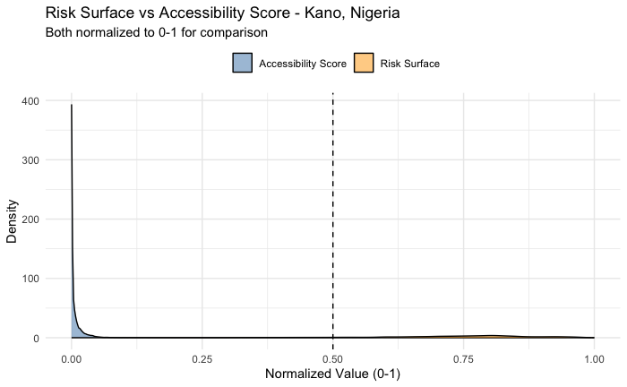

```r
# Extract normalized risk surface values
rr_vec  <- as.vector(terra::values(rr_norm, na.rm = TRUE))

# Use model output Accessibility_standard directly (already normalized)
acc_vec <- as.vector(data$Accessibility_standard)

# Combined density plot
df_combined <- data.frame(
  value  = c(rr_vec, acc_vec),
  source = c(rep("Risk Surface",        length(rr_vec)),
             rep("Accessibility Score", length(acc_vec)))
)

p_compare <- ggplot(df_combined, aes(x = value, fill = source)) +
  geom_density(alpha = 0.5) +
  geom_vline(xintercept = 0.5, linetype = "dashed", color = "black") +
  scale_fill_manual(values = c("Risk Surface"        = "orange",
                               "Accessibility Score" = "steelblue")) +
  labs(
    title    = "Risk Surface vs Accessibility Score - Kano, Nigeria",
    subtitle = "Both normalized to 0-1 for comparison",
    x        = "Normalized Value (0-1)",
    y        = "Density",
    fill     = ""
  ) +
  theme_minimal() +
  theme(legend.position = "top")

print(p_compare)
```